# campaign-exploration-1

## US Presidential Campaign Data Exploration

### Conner Jordan

- This is a recent data set that was plotted using python and the numpy, pandas and matplotlib packages.
- Built in VSCode
- Compiled as part of an exercise from CST 383: Data Science.

An exploration of California campaign contribution data for the 2016 US presidential election.

```python
%matplotlib inline
import numpy as np
import pandas as pd
import matplotlib.pyplot as plt
from matplotlib import rcParams
import seaborn as sns

sns.set()
rcParams['figure.figsize'] = 8, 6
sns.set_context('talk')   # 'talk' for slightly larger
```

```python
# This is a randomly-sampled subset of the full data set.
df = pd.read_csv("https://raw.githubusercontent.com/grbruns/cst383/master/campaign-ca-2016-sample.csv")
```

Which candidates received the most contributions?

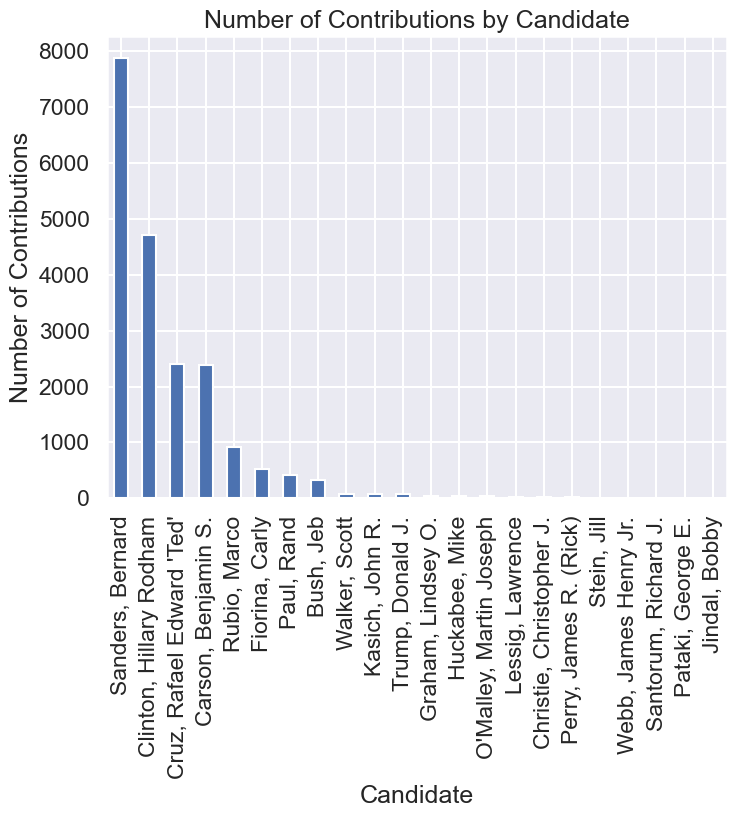

```python
candidate_counts = df['cand_nm'].value_counts()

candidate_counts.plot(kind='bar')
plt.title('Number of Contributions by Candidate')
plt.xlabel('Candidate')
plt.ylabel('Number of Contributions')
plt.show()
```

Let's look at the amount of the contributions, instead of the number of contributions. Which candidates had the highest median contribution amounts?

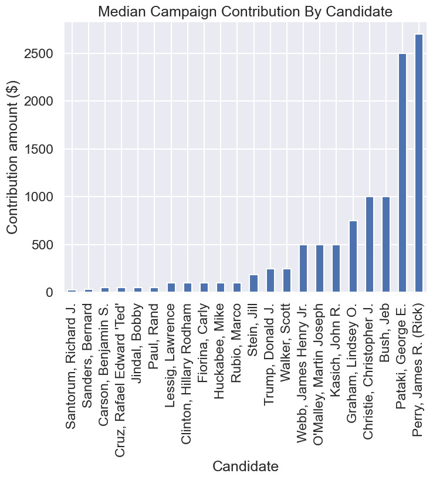

```python
# Calculate median contributions by candidate
median_contributions = df.groupby('cand_nm')['contb_receipt_amt'].median().sort_values(ascending=True)

# Plot
median_contributions.plot(kind='bar')
plt.title('Median Campaign Contribution By Candidate')
plt.xlabel('Candidate')
plt.ylabel('Contribution amount ($)')
plt.show()
```

What is the distribution of the contribution amounts? There are a small number of very large amounts, which make it hard to display the distribution. Also, there are some negative contribution amounts that seem to reflect returned contributions. Therefore, let's focus on contributions ranging from 0 to 3,000 dollars.

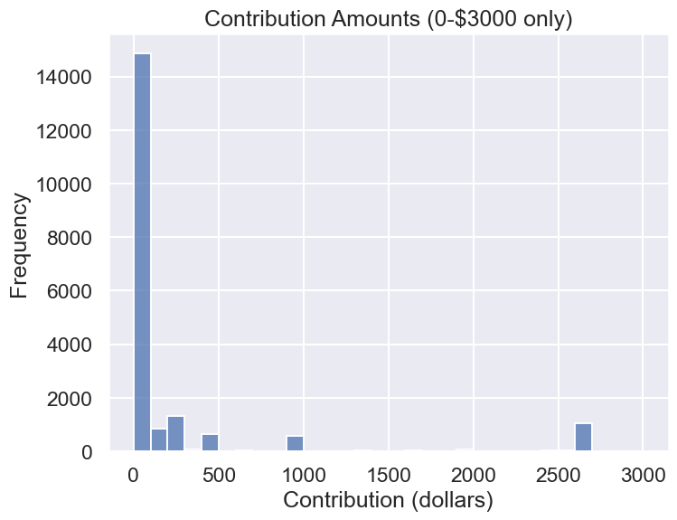

```python
#@ 3 Create a histogram showing contribution amounts.
filtered_df = df[(df['contb_receipt_amt'] > 0) & (df['contb_receipt_amt'] <= 3000)]

sns.histplot(filtered_df['contb_receipt_amt'], bins=30, kde=False)
plt.title('Contribution Amounts (0-$3000 only)')
plt.xlabel('Contribution (dollars)')
plt.ylabel('Frequency')
plt.show()
```

It appears that most contributions are small. Let's restrict our attention to an even smaller range of contributions to get a better idea of how small contributions are distributed.

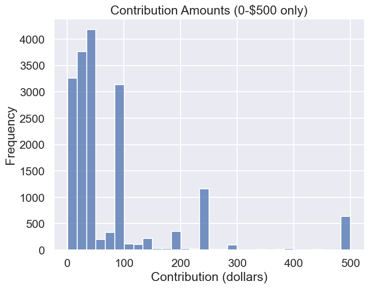

```python
#@ 4 Create a histogram showing contribution
filtered_df_500 = df[(df['contb_receipt_amt'] > 0) & (df['contb_receipt_amt'] <= 500)]

# Plot
sns.histplot(filtered_df_500['contb_receipt_amt'], bins=30, kde=False)
plt.title('Contribution Amounts (0-$500 only)')
plt.xlabel('Contribution (dollars)')
plt.ylabel('Frequency')
plt.show()
```

The appearance of a histogram is sensitive to the number of bins that are used and where the bin edges lie. Let's look at the contribution amounts again using a density plot.

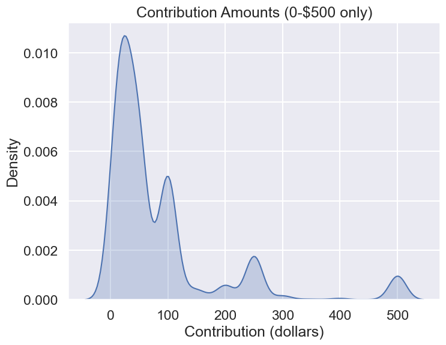

```python
#@ 5 Create a density plot
sns.kdeplot(filtered_df_500['contb_receipt_amt'], fill=True)
plt.title('Contribution Amounts (0-$500 only)')
plt.xlabel('Contribution (dollars)')
plt.ylabel('Density')
plt.show()
```

Let's compare the size of contributions between candidates Rubio and Cruz. Did one of them tend to get larger-sized contributions?

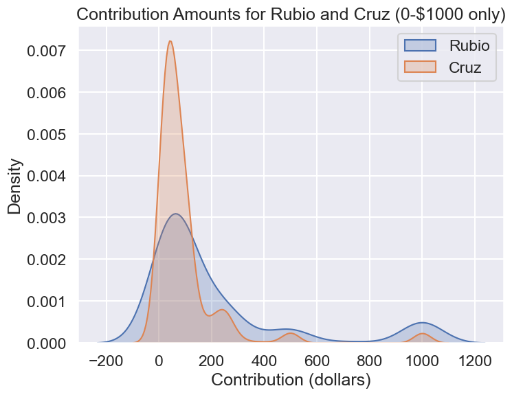

```python
# Problem 6: Double Density Plot for Rubio and Cruz
# Filter out infinite values
rubio_contributions = df[(df['cand_nm'] == 'Rubio, Marco') & (df['contb_receipt_amt'] > 0) & (df['contb_receipt_amt'] <= 1000)]['contb_receipt_amt']
cruz_contributions = df[(df['cand_nm'] == 'Cruz, Rafael Edward \'Ted\'') & (df['contb_receipt_amt'] > 0) & (df['contb_receipt_amt'] <= 1000)]['contb_receipt_amt']

# Plot
sns.kdeplot(rubio_contributions, label='Rubio', fill=True)
sns.kdeplot(cruz_contributions, label='Cruz', fill=True)
plt.title('Contribution Amounts for Rubio and Cruz (0-$1000 only)')
plt.xlabel('Contribution (dollars)')
plt.ylabel('Density')
plt.legend()
plt.show()
```

Rubio and Cruz were Republican candidates. Let's look at a pair of Democratic candidates.

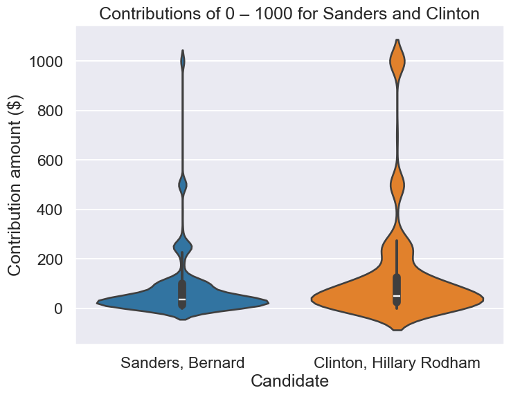

```python
clinton_sanders = df[(df['cand_nm'].isin(['Clinton, Hillary Rodham', 'Sanders, Bernard'])) &
                     (df['contb_receipt_amt'] > 0) &
                     (df['contb_receipt_amt'] <= 1000)]

# Define a custom palette
custom_palette = {"Clinton, Hillary Rodham": "#FF7F0E", "Sanders, Bernard": "#1F77B4"}

# Plot
sns.violinplot(x='cand_nm', y='contb_receipt_amt', data=clinton_sanders, hue='cand_nm', palette=custom_palette, dodge=False, legend=False)
plt.title('Contributions of 0 – 1000 for Sanders and Clinton')
plt.xlabel('Candidate')
plt.ylabel('Contribution amount ($)')
plt.legend([], [], frameon=False)
plt.show()
```

Which occupations are associated with the greatest number of contributions? This will be interesting, but we need to keep in mind that the occupation with the greatest number of contributions might just be the most common occupation.

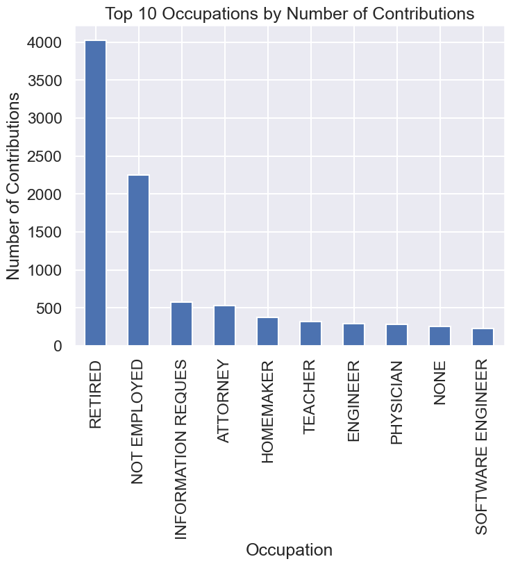

```python
#@ 8 Create a bar plot showing th total number of contributions by occupation,
# for the 10 occupations with the largest number of contributions. Limit the occupation names to 18 characters.
df['short_occ'] = df['contbr_occupation'].str.slice(0, 18)

# Count contributions by occupation
occupation_counts = df['short_occ'].value_counts().head(10)

# Plot
occupation_counts.plot(kind='bar')
plt.title('Top 10 Occupations by Number of Contributions')
plt.xlabel('Occupation')
plt.ylabel('Number of Contributions')
plt.show()
```

We can classify contributors as either employed, unemployed, or retired. Among these groups, which makes the most contributions?

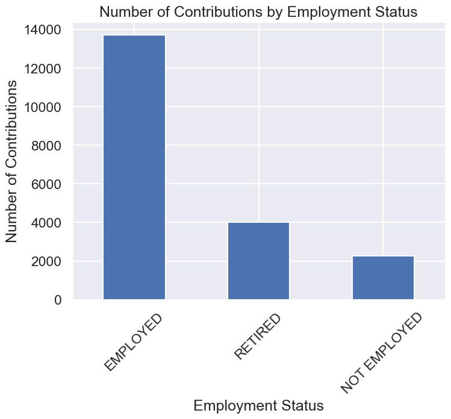

```python
#@ 9 Create a new column "employment_status", derived from the
# contbr_occupation column.
def employment_status(occupation):
    if occupation in ['RETIRED', 'NOT EMPLOYED']:
        return occupation
    else:
        return 'EMPLOYED'

# Apply function
df['employment_status'] = df['contbr_occupation'].apply(employment_status)

# Count contributions by employment status
employment_counts = df['employment_status'].value_counts()

# Plot
employment_counts.plot(kind='bar')
plt.title('Number of Contributions by Employment Status')
plt.xlabel('Employment Status')
plt.ylabel('Number of Contributions')
plt.xticks(rotation=45)
plt.show()
```

Do retired contributors tend to make smaller contributions than employed contributors? It seems likely, but what does the data say?

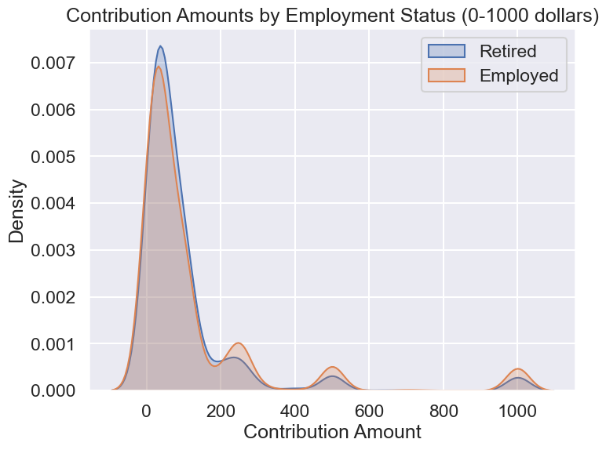

```python
#@ 10 Create a double density plot showing the distribution of
retired_contributions = df[(df['employment_status'] == 'RETIRED') & (df['contb_receipt_amt'] > 0) & (df['contb_receipt_amt'] <= 1000)]
employed_contributions = df[(df['employment_status'] == 'EMPLOYED') & (df['contb_receipt_amt'] > 0) & (df['contb_receipt_amt'] <= 1000)]

# Plot
sns.kdeplot(retired_contributions['contb_receipt_amt'], label='Retired', fill=True)
sns.kdeplot(employed_contributions['contb_receipt_amt'], label='Employed', fill=True)
plt.title('Contribution Amounts by Employment Status (0-1000 dollars)')
plt.xlabel('Contribution Amount')
plt.ylabel('Density')
plt.legend()
plt.show()
```

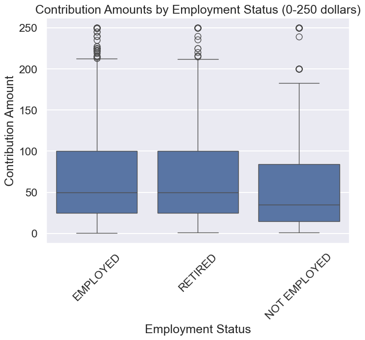

```python
#@ 11 Create a box plot of contribution amounts for each employment
# status category.
filtered_df_250 = df[(df['contb_receipt_amt'] > 0) & (df['contb_receipt_amt'] <= 250)]

# Plot
sns.boxplot(x='employment_status', y='contb_receipt_amt', data=filtered_df_250)
plt.title('Contribution Amounts by Employment Status (0-250 dollars)')
plt.xlabel('Employment Status')
plt.ylabel('Contribution Amount')
plt.xticks(rotation=45)
plt.show()
```

Previously we looked at the number of contributions from different occupations. What about the size of contributions from different occupations? Let's focus on a few occupations that contribute a lot.

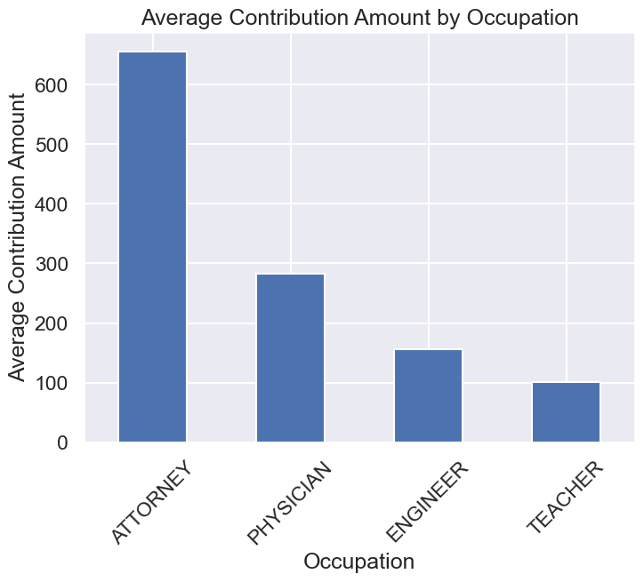

```python
#@ 12 Create a bar plot showing the average contribution amount
# for the occupations 'ATTORNEY', 'TEACHER', 'ENGINEER' and 'PHYSICIAN'.
selected_occupations = df[df['contbr_occupation'].isin(['ATTORNEY', 'TEACHER', 'ENGINEER', 'PHYSICIAN'])]

# Calculate mean contributions by occupation
mean_contributions = selected_occupations.groupby('contbr_occupation')['contb_receipt_amt'].mean().sort_values(ascending=False)

# Plot
mean_contributions.plot(kind='bar')
plt.title('Average Contribution Amount by Occupation')
plt.xlabel('Occupation')
plt.ylabel('Average Contribution Amount')
plt.xticks(rotation=45)
plt.show()
```